# Informe del Proyecto

Rosalia

2025-08-08

```r
paquetes_necesarios <- c(
  "flexdashboard", "tidyverse", "readxl", "readr", "dplyr", "ggplot2",
  "ggrepel", "countrycode", "scales", "maps", "DT", "lorem", "png", "grid"
)

instalar_si_falta <- function(pkg) {
  if (!requireNamespace(pkg, quietly = TRUE)) {
    install.packages(pkg)
  }
}

invisible(lapply(paquetes_necesarios, instalar_si_falta))

message("Todos los paquetes necesarios están instalados.")
```

```
## Todos los paquetes necesarios están instalados.
```

```r
library(tidyverse)
```

```r
library(readxl)
library(readr)
library(dplyr)
library(ggplot2)
library(ggrepel)
library(countrycode)
library(scales)
library(maps)
library(DT)
library(lorem)
library(png)
library(grid)
library(tinytex)
library(corrplot)
library(here)
```

**Introducción**

Esta propuesta de diseñar una investigación en ciencias de datos me brinda la libertad de explorar con mayor profundidad temas sociales que me atraviesan personalmente. Al revisar las bases de datos disponibles en Gapminder, encontré una gran variedad de información relacionada con las mujeres, lo que despertó en mí una inquietud sobre la posible relación entre la longevidad femenina y la maternidad. En Costa Rica, existe una expresión popular según la cual “tener hijos te riega las bilis”, lo que en el imaginario colectivo podría asociarse con la idea de que la maternidad acorta la vida. Esta creencia me llevó a preguntarme si realmente existe una relación significativa entre la esperanza de vida de las mujeres y la cantidad promedio de hijos o hijas que tienen. En lo personal, mi familia ilustra esta interrogante de forma particular. Mi madre tuvo una sola hermana, quien no tuvo hijos y falleció a una edad relativamente baja para los estándares actuales. Por otro lado, espero que mi madre —quien sí tuvo hijos— viva muchos más años que el promedio nacional. Aunque anecdótica, esta observación familiar me motivó a profundizar en la investigación científica sobre el tema.

Entre los estudios que llamaron mi atención fue Vaupel (2001) plantea que podría existir una relación positiva entre el número de hijos y la longevidad en las mujeres, especialmente cuando el último parto ocurre a una edad avanzada. Por su parte, Zhang et al. (2023) afirman que las mujeres que tienen entre tres y cinco hijos tienden a vivir más tiempo, mientras que aquellas con uno o ningún hijo presentan una esperanza de vida más corta. Me resulta interesante cómo estas investigaciones se reflejan, de alguna forma, en la experiencia de mi propia familia.

Por otro lado, Hampton (2021) analiza la relación entre desarrollo y fecundidad, señalando que, aunque existe la idea de que a mayor desarrollo económico se podría esperar un aumento de la fecundidad, en la práctica no se observa una asociación directa. Su estudio concluye que, al menos en la última década, los niveles elevados de desarrollo humano ya no están vinculados con repuntes en la tasa de natalidad.

Ahora bien, Ziepple, Reeve y Peniston (2024) realizaron un estudio sobre la relación entre maternidad y esperanza de vida, en el cual plantean que la interacción madre-cría desempeña un papel fundamental en la extensión de la vida tanto en primates humanos como no humanos. A través de la formulación de hipótesis evolutivas, concluyen que la conexión entre la supervivencia materna y la aptitud reproductiva —entendida como el éxito de la descendencia— puede favorecer vidas más largas con menor frecuencia reproductiva. Este hallazgo sugiere que, en ciertos contextos, la longevidad podría estar más vinculada al cuidado prolongado que al número de hijos, abriendo nuevas perspectivas sobre el vínculo entre maternidad y salud a largo plazo.

Este estudio se inserta en uno de los debates sobre el crecimiento poblacional, en el cual se observa que la población sigue en aumento. Sin embargo, dependiendo del continente, el debate se matiza según la cantidad de hijos por mujer.

En este contexto, considero relevante abrir la discusión sobre lo que representa la decisión de tener hijos y su posible vínculo con la longevidad. Estos hallazgos no solo enriquecen el debate científico, sino que también invitan a repensar la maternidad desde una perspectiva más informada, contextualizada y consciente de sus implicaciones a largo plazo.

**Objetivos**

Ante estas inquietudes el Objetivo General es:

Analizar la relación entre la esperanza de vida femenina, la fecundidad y el nivel de desarrollo económico en países del mundo, utilizando datos históricos de Gapminder entre 1950 y 2021

En cuanto a los objetivos específicos son:

1. Comparar la esperanza de vida femenina, la fecundidad y el producto interno bruto per cápita entre regiones geográficas y a lo largo del tiempo, para identificar asociaciones significativas y variaciones contextuales
2. Explorar combinaciones bivariadas entre esperanza de vida femenina, fecundidad y PIB per cápita para identificar patrones y tendencias que evidencien diferencias significativas entre países con distintos niveles de desarrollo económico.
3. Evaluar la relación conjunta entre PIB per cápita, fecundidad y esperanza de vida femenina, con el fin de caracterizar la correlación multivariable y su comportamiento en distintos contextos socioeconómicos.
4. Diseñar y presentar un dashboard interactivo que visualice los hallazgos derivados del análisis de las tres variables, facilitando la exploración dinámica de patrones por región, año y nivel de desarrollo económico.

**Metodología de investigación**

Esta investigación se basa en un enfoque exploratorio utilizando información agregada a nivel país, lo que permite analizar datos históricos sobre fecundidad, esperanza de vida y producto interno bruto per cápita. Es importante aclarar que, debido a la naturaleza agregada de los datos, no es posible establecer relaciones causales individuales. Lo que se observa son asociaciones a nivel macro, que pueden orientar futuras investigaciones más específicas.

Como se menciona en los objetivos, he decidido trabajar con tres conjuntos de datos disponibles en Gapminder para desarrollar un análisis exploratorio de datos: • Life_expectancy_female: esperanza de vida al nacer de mujeres (en años). • Children_per_women_total_fertility: número promedio de hijos por mujer a lo largo de su vida. • Gross domestic product per person: producto interno bruto per cápita ajustado por paridad de poder adquisitivo al año 2021. Estos conjuntos de datos cubren periodos desde 1800 hasta 2021, por lo que el análisis se centrará en los datos comunes disponibles a partir de 1950.

Al revisar las bases de datos utilizadas, se identifican cinco variables principales: year, country, esperanza_de_vida, nacimientos_por_mujer y producto_por_capita.

Las variables principales utilizadas fueron: *year*, *country*, *esperanza_de_vida*, *nacimientos_por_mujer* y *producto_por_capita*. Aunque Gapminder actualiza sus datos periódicamente, la mayoría de las series disponibles tienen como año más reciente el 2021. Dado que se trata de indicadores globales comparables entre países, la actualización depende de fuentes oficiales como el Banco Mundial o la ONU. Por ello, se recomienda revisar las series anualmente, aunque algunas pueden actualizarse con menor frecuencia.

**Datos Utilizados**

```r
Datos_FEGDP <- readr::read_csv(
  here("Datos", "Base_Datos_depurada", "base_completa.csv"),
  locale = locale(encoding = "UTF-8")
)
Vars <- paste0(c("esperanza_de_vida", "producto_por_capita", "nacimientos_por_mujer", "continente", "gdp_grupo"))
```

Los paises que se encuentran en la base de datos fueron:

```r
unique(Datos_FEGDP$country)
```

```
##   [1] "Aruba"                          "Afghanistan"
##   [3] "Angola"                         "Anguilla"
##   [5] "Albania"                        "Andorra"
##   [7] "UAE"                            "Argentina"
##   [9] "Armenia"                        "American Samoa"
##  [11] "Antigua and Barbuda"            "Australia"
##  [13] "Austria"                        "Azerbaijan"
##  [15] "Burundi"                        "Belgium"
##  [17] "Benin"                          "Burkina Faso"
##  [19] "Bangladesh"                     "Bulgaria"
##  [21] "Bahrain"                        "Bahamas"
##  [23] "Bosnia and Herzegovina"         "Belarus"
##  [25] "Belize"                         "Bermuda"
##  [27] "Bolivia"                        "Brazil"
##  [29] "Barbados"                       "Brunei"
```

[output cut: 103 more lines]

**Preparación de los Datos**

Para la preparación y análisis de los datos se utilizó el lenguaje de programación R, dada su capacidad para realizar análisis estadísticos, visualizaciones y transformaciones de datos de forma eficiente

Durante la depuración de los datos se identificaron outliers al explorar la variable esperanza de vida femenina al nacer y la tasa de fecundidad (nacimientos por mujer). Utilizando técnicas estadísticas (por ejemplo, el método del rango intercuartílico), se detectaron aproximadamente: • 1175 valores atípicos en la variable de esperanza de vida. • 765 valores atípicos en la variable de fecundidad. Estos valores extremos pueden deberse a múltiples factores, como conflictos armados, crisis sanitarias, cambios abruptos en la política pública o deficiencias en el registro estadístico. Además, reflejan la alta variabilidad entre países y a lo largo del tiempo, por lo que deben ser considerados con atención en el análisis. No necesariamente deben ser eliminados, ya que pueden contener información relevante para explicar fenómenos estructurales.

Se realizaron transformaciones adicionales para corregir errores en nombres de países y se generaron nuevas variables categóricas, como continente y nivel de GDP (alto/bajo)

Para el análisis de los datos se empleó la estadística descriptiva e inferencial y se utilizaron las siguientes librerías de R - tidyverse - readxl - readr - dplyr - ggplot2 - ggrepel - countrycode - scales - maps - DT - lorem - png - grid - tinytex

**Visualización**

Se emplearon diversos tipos de gráficos para explorar las relaciones entre variables 1. Boxplot: a. Función: Comparar la distribución de una variable continua entre grupos categóricos. b. Aplicación: Se utilizará para mostrar diferencias en la esperanza de vida según continente, nivel de GDP (alto/bajo) o año.

**Reproducibilidad**

Para garantizar la reproducibilidad del análisis se utilizaron herramientas como RStudio, RMarkdown y Git/GitHub, permitiendo documentar el proceso, versionar el código y compartir los resultados de forma transparente.

**Resultados Generales**

A partir de las investigaciones presentadas en la introducción, surge la pregunta central ¿Tener menos hijos realmente alarga la esperanza de vida femenina, o tener entre dos y cinco hijos genera un efecto similar?

Este interrogante guía el análisis exploratorio presentado en el dashboard. En particular, el gráfico que relaciona fecundidad y esperanza de vida muestra una tendencia general decreciente: A mayor número de hijos por mujer, menor esperanza de vida.

Este patrón sugiere que podría existir una relación inversa entre reproducción y longevidad, aunque se requiere un análisis más profundo para considerar factores contextuales y causales.

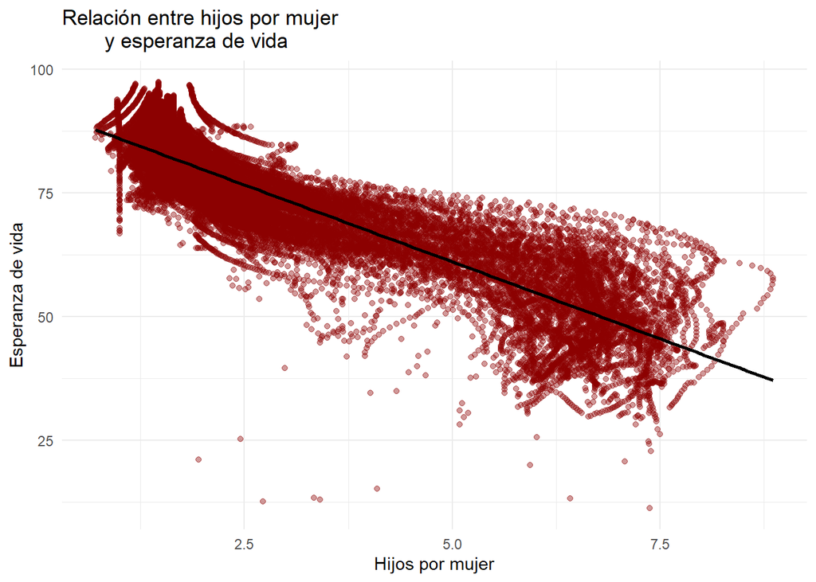

```r
datos_filtrados <- Datos_FEGDP

ggplot(datos_filtrados, aes(x = nacimientos_por_mujer, y = esperanza_de_vida)) +
  geom_point(alpha = 0.4, color = "darkred") +
  geom_smooth(method = "lm", se = FALSE, color = "black") +
  labs(title = "Relación entre hijos por mujer
       y esperanza de vida", x = "Hijos por mujer", y = "Esperanza de vida") +
  theme_minimal()
```

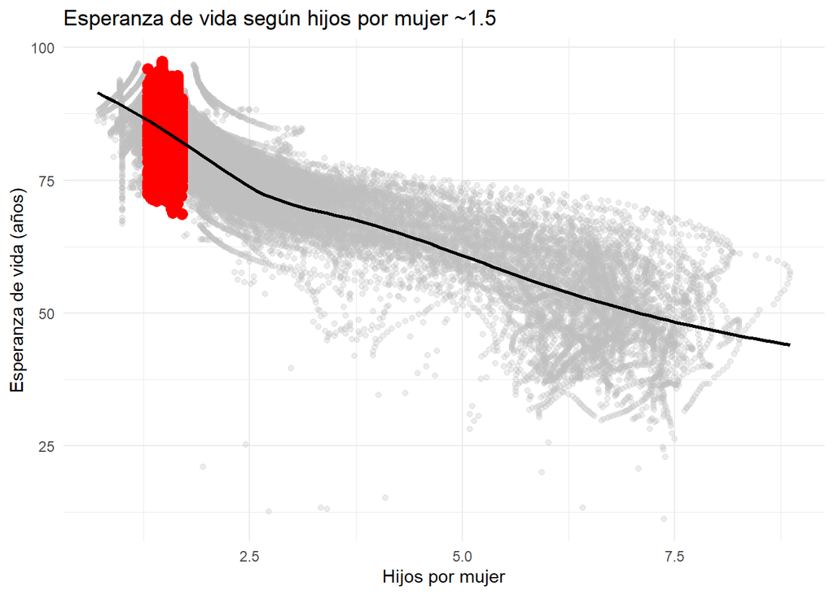

```r
 hijos <- 1.5

  # Filtrar datos según 2 hijos
  datos_filtrados <- Datos_FEGDP %>%
    filter(!is.na(nacimientos_por_mujer),
      !is.na(esperanza_de_vida)
    ) %>%
    filter(abs(nacimientos_por_mujer - hijos) < 0.2)

#Gráfico
 ggplot(Datos_FEGDP, aes(x = nacimientos_por_mujer, y = esperanza_de_vida)) +
    geom_point(alpha = 0.3, color = "gray") +
    geom_point(data = datos_filtrados, aes(x = nacimientos_por_mujer, y = esperanza_de_vida),
               color = "red", size = 3) +
    geom_smooth(method = "loess", se = FALSE, color = "black") +
    labs(
      title = paste("Esperanza de vida según hijos por mujer",
                    if (!is.na(hijos)) paste0("~", hijos) else ""),
      x = "Hijos por mujer",
      y = "Esperanza de vida (años)"
    ) +
    theme_minimal()
```

Se realiza una prueba de correlación de Pearson y Spearman para identificar correlaciones positivas como negativas.

```r
# Filtrar datos si deseas hacerlo por año específico (opcional)
datos_filtrados <- Datos_FEGDP %>% filter(year == 2000)

# Seleccionar solo las variables numéricas de interés
variables <- datos_filtrados %>%
  select(esperanza_de_vida, producto_por_capita, nacimientos_por_mujer)
# Correlación de Pearson
cor_pearson <- cor(variables, method = "pearson", use = "complete.obs")

# Correlación de Spearman
cor_spearman <- cor(variables, method = "spearman", use = "complete.obs")

# Mostrar resultados
print("Correlación de Pearson:")
```

```
## [1] "Correlación de Pearson:"
```

```r
print(round(cor_pearson, 3))
```

```
##                       esperanza_de_vida producto_por_capita
## esperanza_de_vida                 1.000                0.60
## producto_por_capita               0.600                1.00
## nacimientos_por_mujer            -0.856               -0.47
##                       nacimientos_por_mujer
## esperanza_de_vida                    -0.856
## producto_por_capita                  -0.470
## nacimientos_por_mujer                 1.000
```

```r
print("Correlación de Spearman:")
```

```
## [1] "Correlación de Spearman:"
```

```r
print(round(cor_spearman, 3))
```

```
##                       esperanza_de_vida producto_por_capita
## esperanza_de_vida                 1.000               0.870
## producto_por_capita               0.870               1.000
## nacimientos_por_mujer            -0.823              -0.742
##                       nacimientos_por_mujer
## esperanza_de_vida                    -0.823
## producto_por_capita                  -0.742
## nacimientos_por_mujer                 1.000
```

Tanto en los gráficos generales como en las pruebas se puede ver que hay una correlación positiva entre esperanza de vida y PIB, mientras que hay una negativa entre esperanza de vida y fecundidad, lo mismo que se puede ver en los gráficos, a su vez, también se puede ver una correlación negativa entre el PIB per cápita y la fecundidad.

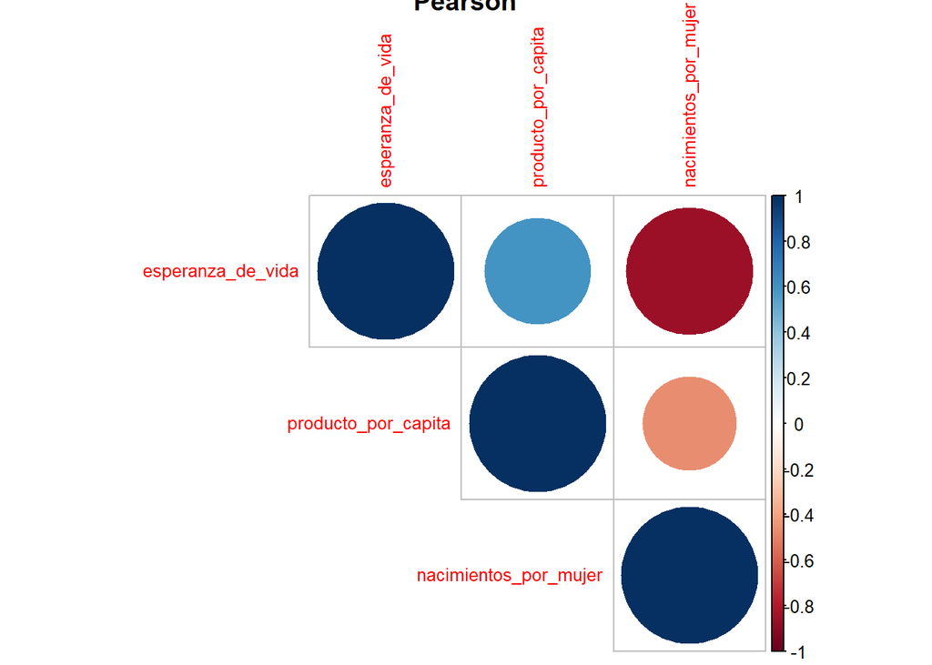

```r
# Visualizar matriz de Pearson
corrplot(cor_pearson, method = "circle", type = "upper", tl.cex = 0.8, title = "Pearson")
```

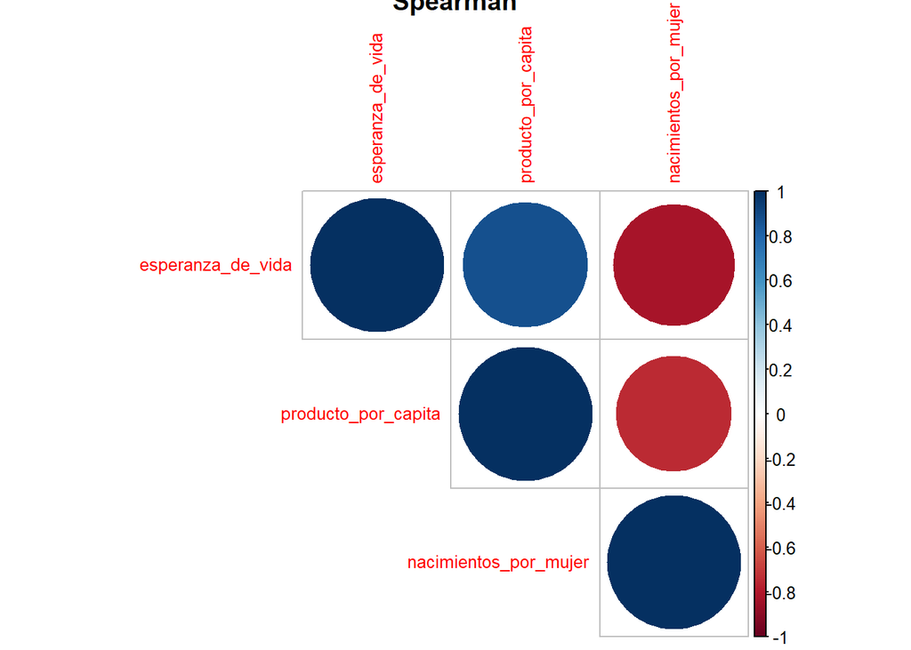

```r
# Visualizar matriz de Spearman
corrplot(cor_spearman, method = "circle", type = "upper", tl.cex = 0.8, title = "Spearman")
```

Los resultados respaldan los patrones visuales observados anteriormente mediante gráficos.

**Análisis Regional**

Europa presenta un comportamiento particular: Se observa una caída en la cantidad de hijos por mujeres y con esto también la esperanza de vida en países con 2 hijos por mujer, aunque no se trata de una reducción sistemática. De hecho, varios países con solo 1 hijo muestran menor esperanza de vida que aquellos con 2, lo cual podría deberse a factores contextuales como el envejecimiento poblacional o las políticas de salud.

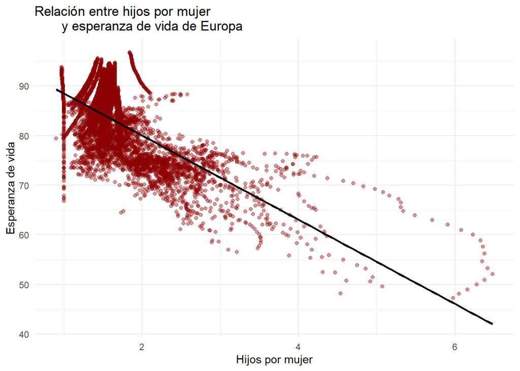

```r
datos_filtrados <- Datos_FEGDP %>%
  filter(continente == "Europe")

ggplot(datos_filtrados, aes(x = nacimientos_por_mujer, y = esperanza_de_vida)) +
  geom_point(alpha = 0.4, color = "darkred") +
  geom_smooth(method = "lm", se = FALSE, color = "black") +
  labs(title = "Relación entre hijos por mujer
       y esperanza de vida de Europa", x = "Hijos por mujer", y = "Esperanza de vida") +
  theme_minimal()
```

En el caso de África, se registra la esperanza de vida más baja en comparación con otros continentes, manteniéndose la tendencia decreciente a pesar de una alta fecundidad.

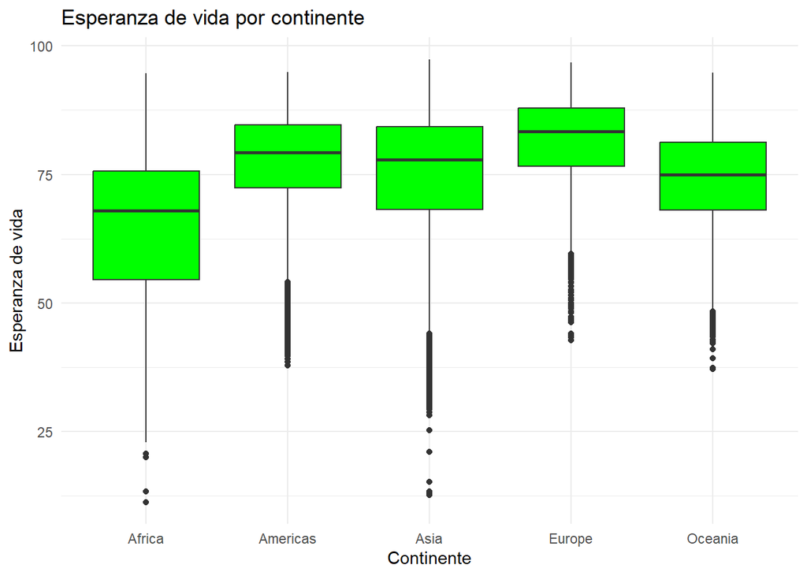

```r
ggplot(Datos_FEGDP, aes(x = continente, y = esperanza_de_vida)) +
  geom_boxplot(fill = "green") +
  labs(title = "Esperanza de vida por continente", y = "Esperanza de vida", x = "Continente") +
  theme_minimal()
```

Continuando con la misma región, el bajo nivel del PIB per cápita también resalta como un elemento que podría influir en los resultados, reflejando bajos niveles de desarrollo económico.

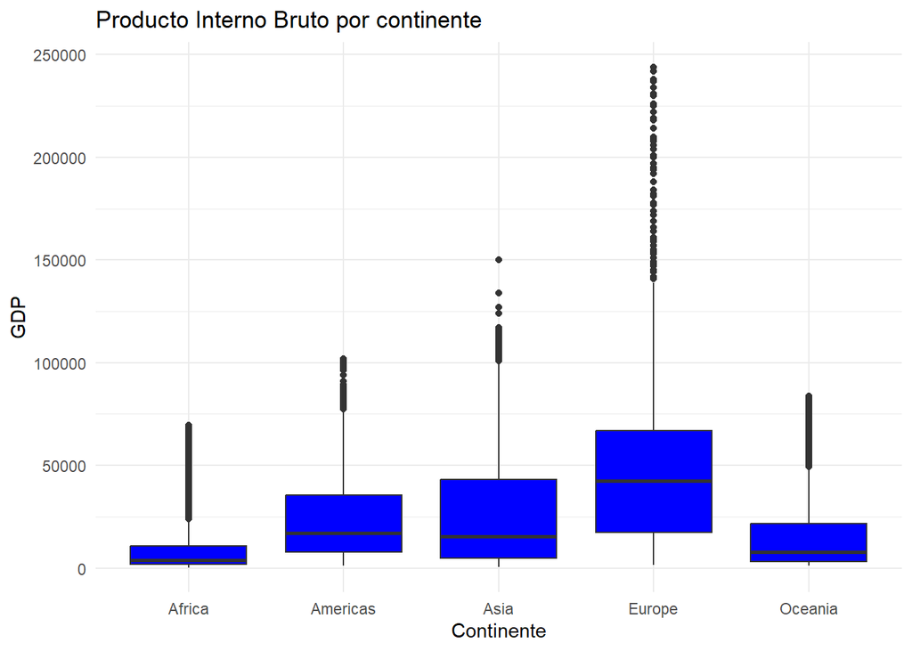

```r
ggplot(Datos_FEGDP, aes(x = continente, y = producto_por_capita)) +
  geom_boxplot(fill = "blue") +
  labs(title = "Producto Interno Bruto por continente", y = "GDP", x = "Continente") +
  theme_minimal()
```

En las Américas, se conserva la tendencia general: los países con mayor fecundidad tienden a registrar niveles más bajos de esperanza de vida. Este patrón refuerza la hipótesis de una correlación negativa entre estas dos variables, aunque no necesariamente causal.

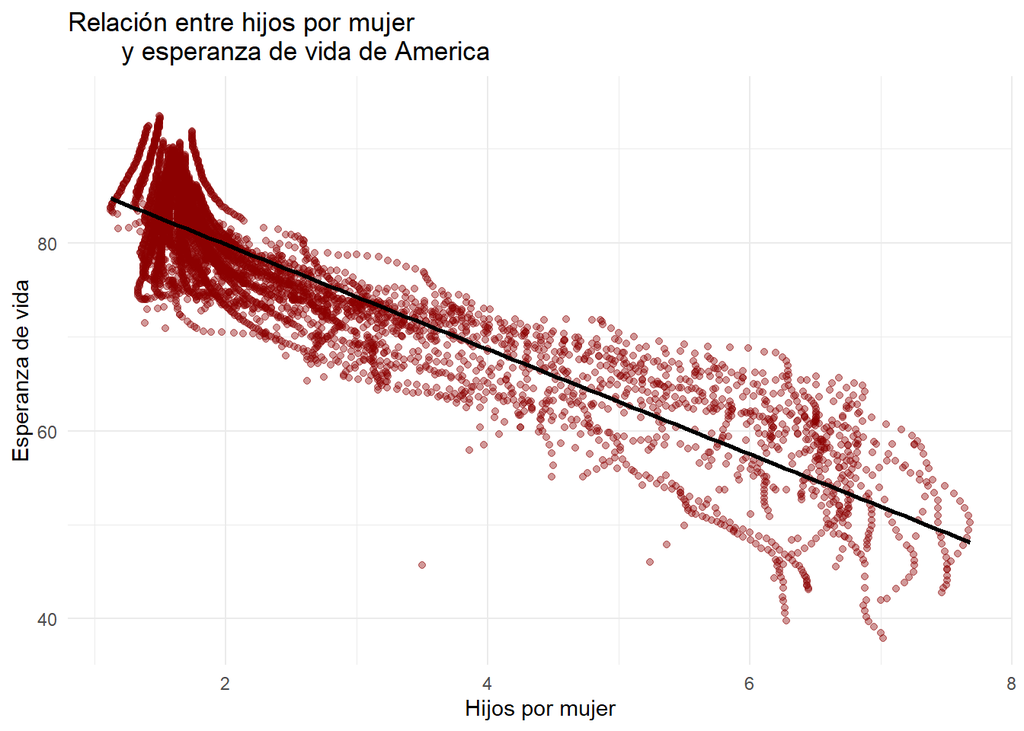

```r
datos_filtrados <- Datos_FEGDP %>%
  filter(continente == "Americas")

ggplot(datos_filtrados, aes(x = nacimientos_por_mujer, y = esperanza_de_vida)) +
  geom_point(alpha = 0.4, color = "darkred") +
  geom_smooth(method = "lm", se = FALSE, color = "black") +
  labs(title = "Relación entre hijos por mujer
       y esperanza de vida de America", x = "Hijos por mujer", y = "Esperanza de vida") +
  theme_minimal()
```

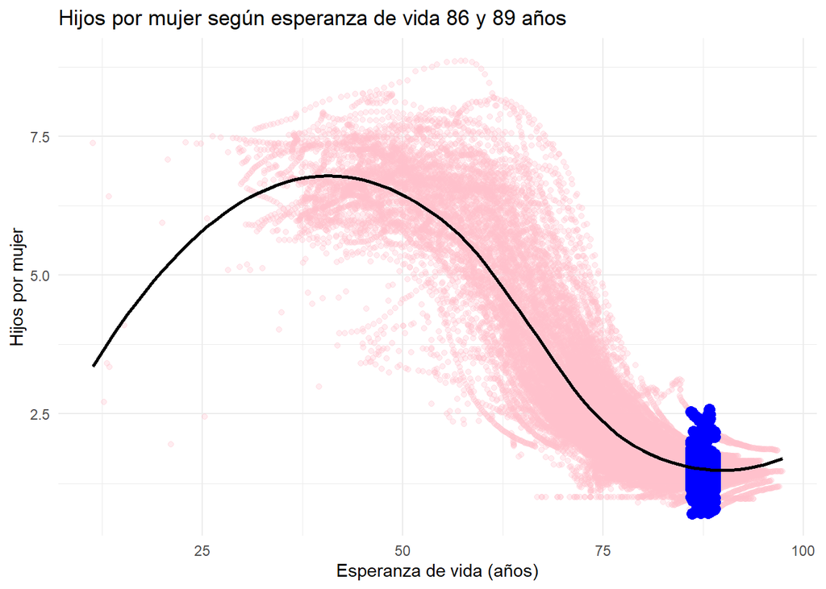

```r
vida_min <- 86
vida_max <- 89

  # Filtrar datos según los inputs
  datos_filtrados <- Datos_FEGDP %>%
    filter(!is.na(nacimientos_por_mujer),
      !is.na(esperanza_de_vida)
    ) %>%
    filter(esperanza_de_vida >= vida_min & esperanza_de_vida <= vida_max)

#Gráfico
 ggplot(Datos_FEGDP, aes(x = esperanza_de_vida, y = nacimientos_por_mujer)) +
    geom_point(alpha = 0.3, color = "pink") +
    geom_point(data = datos_filtrados, aes(x = esperanza_de_vida, y = nacimientos_por_mujer),
               color = "blue", size = 3) +
    geom_smooth(method = "loess", se = FALSE, color = "black") +
    labs(
      title = paste("Hijos por mujer según esperanza de vida",
                    vida_min, "y", vida_max, "años"),
      x = "Esperanza de vida (años)",
      y = "Hijos por mujer"
    ) +
    theme_minimal()
```

Por otro lado, los países con una fecundidad de 1 hijo muestran una esperanza de vida aún mayor, entre 93 y 96 años. Esto sugiere que los países con baja fecundidad tienden a presentar mayores niveles de longevidad. Sin embargo, no se observa un patrón lineal estricto: no puede afirmarse que a menor número de hijos por mujer siempre corresponda una mayor esperanza de vida.

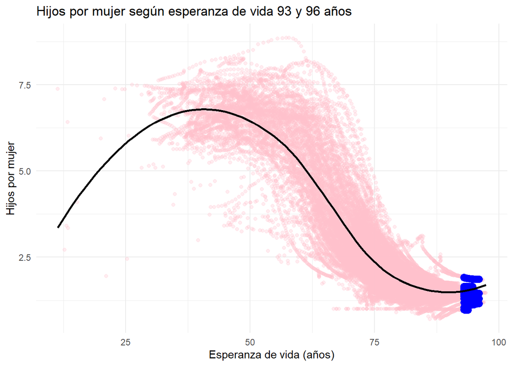

```r
vida_min1 <- 93
vida_max2 <- 96

  # Filtrar datos según los inputs
  datos_filtrados <- Datos_FEGDP %>%
    filter(!is.na(nacimientos_por_mujer),
      !is.na(esperanza_de_vida)
    ) %>%
    filter(esperanza_de_vida >= vida_min1 & esperanza_de_vida <= vida_max2)

#Gráfico
 ggplot(Datos_FEGDP, aes(x = esperanza_de_vida, y = nacimientos_por_mujer)) +
    geom_point(alpha = 0.3, color = "pink") +
    geom_point(data = datos_filtrados, aes(x = esperanza_de_vida, y = nacimientos_por_mujer),
               color = "blue", size = 3) +
    geom_smooth(method = "loess", se = FALSE, color = "black") +
    labs(
      title = paste("Hijos por mujer según esperanza de vida",
                    vida_min1, "y", vida_max2, "años"),
      x = "Esperanza de vida (años)",
      y = "Hijos por mujer"
    ) +
    theme_minimal()
```

Aunque no se puede concluir que tener hijos necesariamente alarga o acorta la vida, los gráficos permiten identificar tendencias consistentes, especialmente al analizar los datos por regiones o niveles de desarrollo económico.

En cuanto al PIB per cápita, el gráfico de interacción avanzada muestra cómo esta variable se asocia tanto con fecundidad como con esperanza de vida. En el gráfico “Relación entre GDP, fecundidad y esperanza de vida”, se observa que los países con PIB superiores a 100,000 dólares se ubican principalmente en la franja de 2 a 2.5 hijos por mujer, y presentan una esperanza de vida alta (representada en color azul). Esto evidencia que, si bien la baja fecundidad puede asociarse con mayor longevidad, el nivel de desarrollo económico es un factor modulador clave.

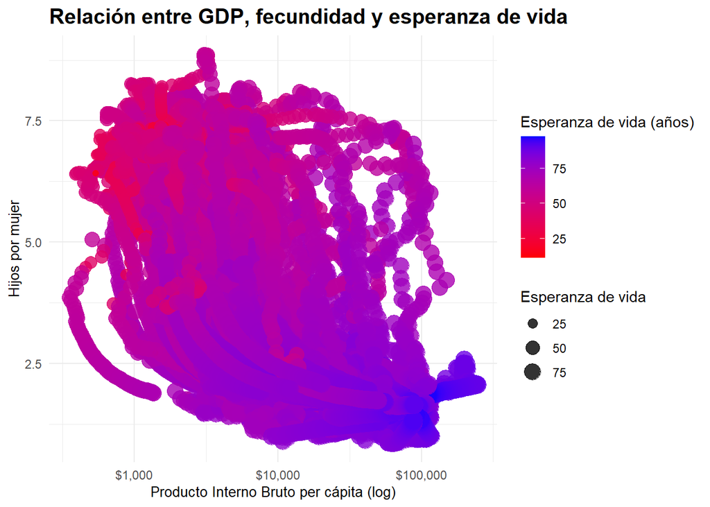

```r
  datos_filtrados <- Datos_FEGDP %>%
    filter(
      !is.na(producto_por_capita),
      !is.na(nacimientos_por_mujer),
      !is.na(esperanza_de_vida)
)

# Gráfico
ggplot(datos_filtrados, aes(x = producto_por_capita,
                            y = nacimientos_por_mujer,
                            size = esperanza_de_vida,
                            color = esperanza_de_vida)) +
  geom_point(alpha = 0.8) +
  scale_x_log10(labels = dollar_format(prefix = "$")) +
  scale_color_gradient(low = "red", high = "blue") +
  labs(title = "Relación entre GDP, fecundidad y esperanza de vida",
       x = "Producto Interno Bruto per cápita (log)",
       y = "Hijos por mujer",
       color = "Esperanza de vida (años)",
       size = "Esperanza de vida") +
  theme_minimal()+
  theme(
    plot.title = element_text(size = 15, face = "bold"),
    axis.title = element_text(size = 10)
  )
```

Al comparar países según sus niveles de ingreso, se observa que en aquellos con mayor PIB per cápita, la relación entre baja fecundidad y alta esperanza de vida es más clara y estable. En contraste, los países con ingresos bajos presentan relaciones más dispersas, posiblemente influenciadas por factores externos como conflictos, pobreza estructural o debilidad institucional.

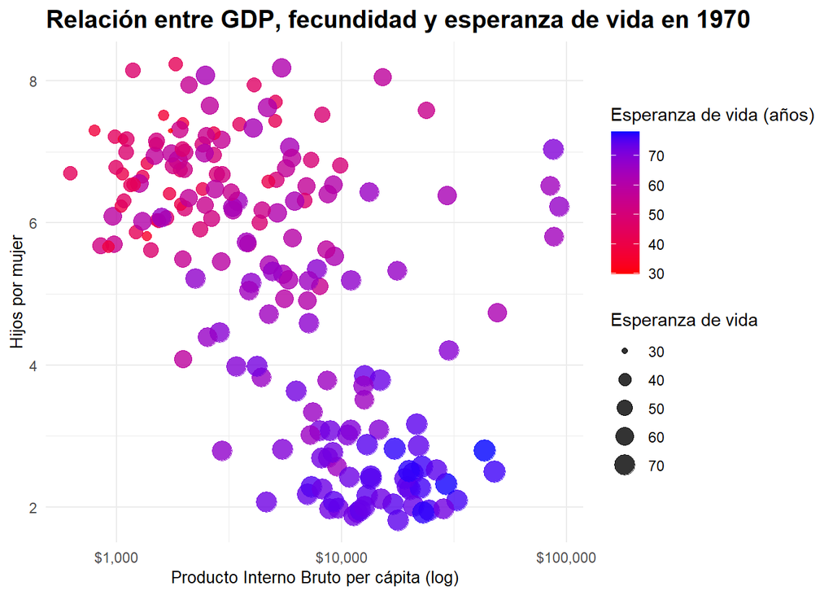

```r
  datos_filtrados <- Datos_FEGDP %>%
    filter( year == 1970,
      !is.na(producto_por_capita),
      !is.na(nacimientos_por_mujer),
      !is.na(esperanza_de_vida)
)

# Gráfico
ggplot(datos_filtrados, aes(x = producto_por_capita,
                            y = nacimientos_por_mujer,
                            size = esperanza_de_vida,
                            color = esperanza_de_vida)) +
  geom_point(alpha = 0.8) +
  scale_x_log10(labels = dollar_format(prefix = "$")) +
  scale_color_gradient(low = "red", high = "blue") +
  labs(title = "Relación entre GDP, fecundidad y esperanza de vida en 1970",
       x = "Producto Interno Bruto per cápita (log)",
       y = "Hijos por mujer",
       color = "Esperanza de vida (años)",
       size = "Esperanza de vida") +
  theme_minimal()+
  theme(
    plot.title = element_text(size = 15, face = "bold"),
    axis.title = element_text(size = 10)
  )
```

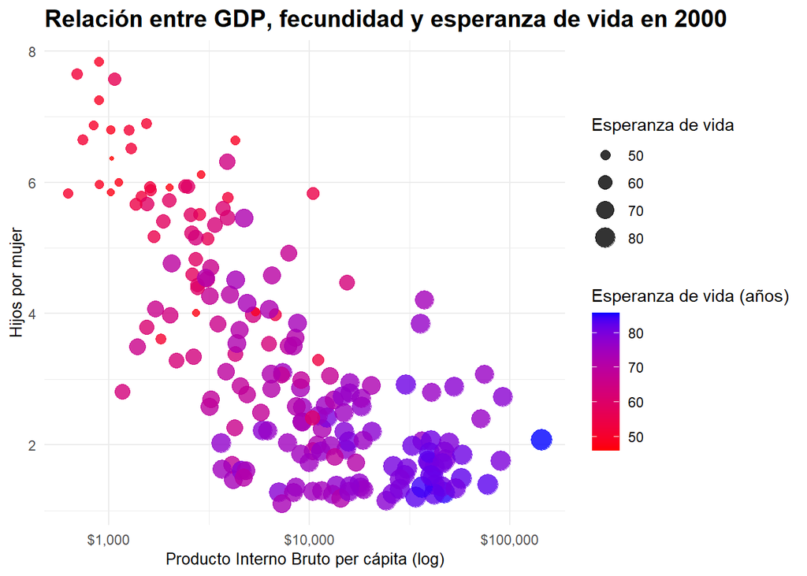

```r
  datos_filtrados <- Datos_FEGDP %>%
    filter( year == 2000,
      !is.na(producto_por_capita),
      !is.na(nacimientos_por_mujer),
      !is.na(esperanza_de_vida)
)

# Gráfico
ggplot(datos_filtrados, aes(x = producto_por_capita,
                            y = nacimientos_por_mujer,
                            size = esperanza_de_vida,
                            color = esperanza_de_vida)) +
  geom_point(alpha = 0.8) +
  scale_x_log10(labels = dollar_format(prefix = "$")) +
  scale_color_gradient(low = "red", high = "blue") +
  labs(title = "Relación entre GDP, fecundidad y esperanza de vida en 2000",
       x = "Producto Interno Bruto per cápita (log)",
       y = "Hijos por mujer",
       color = "Esperanza de vida (años)",
       size = "Esperanza de vida") +
  theme_minimal()+
  theme(
    plot.title = element_text(size = 15, face = "bold"),
    axis.title = element_text(size = 10)
  )
```

Aunque la fecundidad no constituye un determinante único en la decisión de tener hijos ni en la esperanza de vida, sí representa un componente clave en el análisis con perspectiva de género. Las decisiones reproductivas están profundamente influenciadas por factores sociales, económicos y culturales, que varían según el contexto y el nivel de desarrollo.

Además, existen otras perspectivas que no pudieron abordarse en esta investigación debido a la falta de información disponible, como el rol del compañero o compañera de crianza, así como la presencia de redes de apoyo familiares, comunitarias o institucionales. Estos factores pueden influir significativamente en la experiencia reproductiva, el bienestar emocional y la salud a largo plazo de las mujeres, y podrían ser determinantes en la relación entre maternidad y longevidad. Su inclusión en futuros estudios permitiría ampliar el análisis hacia una comprensión más integral del contexto en que se toman las decisiones reproductivas y se vive la maternidad.

En este estudio, la regresión múltiple revela que el PIB per cápita y la fecundidad explican conjuntamente más del 84% de la variabilidad en la esperanza de vida femenina. Este resultado evidencia una correlación multivariable sólida entre desarrollo económico, salud y dinámica demográfica, y refuerza la necesidad de abordar los indicadores poblacionales desde una mirada integrada y contextualizada.

Además, estos hallazgos se alinean con estudios previos que sugieren un vínculo entre decisiones reproductivas y longevidad femenina. Si bien no se puede establecer una relación causal directa, los datos apuntan a que niveles moderados de fecundidad —como tener un solo hijo— podrían asociarse con una mayor esperanza de vida, especialmente en contextos con mejores condiciones socioeconómicas.

```r
# Modelo de regresión múltiple
modelo <- lm(variables, data = Datos_FEGDP)

# Resumen del modelo
summary(modelo)
```

```
##
## Call:
## lm(formula = variables, data = Datos_FEGDP)
##
## Residuals:
##     Min      1Q  Median      3Q     Max
## -58.855  -2.576   0.313   3.099  19.957
##
## Coefficients:
##                         Estimate Std. Error t value Pr(>|t|)
## (Intercept)            8.533e+01  8.738e-02   976.5   <2e-16 ***
## producto_por_capita    1.442e-04  1.353e-06   106.5   <2e-16 ***
## nacimientos_por_mujer -5.139e+00  1.945e-02  -264.2   <2e-16 ***
## ---
## Signif. codes:  0 '***' 0.001 '**' 0.01 '*' 0.05 '.' 0.1 ' ' 1
##
## Residual standard error: 5.146 on 28082 degrees of freedom
##   (7551 observations deleted due to missingness)
## Multiple R-squared:  0.8469, Adjusted R-squared:  0.8469
## F-statistic: 7.766e+04 on 2 and 28082 DF,  p-value: < 2.2e-16
```

**Construcción del Dashboard**

La creación de un dashboard permite visualizar información que, por otros medios, no sería posible explorar con la misma claridad. El dashboard titulado “Relación entre fecundidad, esperanza de vida de las mujeres y el Producto Interno Bruto (PIB)” fue desarrollado con el propósito de cumplir los objetivos planteados previamente. Para su diseño, se tomó como referencia el boceto propuesto en el Reto 1.

Aunque no se logró replicar visualmente el diseño del boceto original debido a las limitaciones propias en la herramienta en R, sí fue posible implementar una funcionalidad que permite consultar la información de forma efectiva y dinámica.

En la primera sección del dashboard, el objetivo era ofrecer una visión general de las tres variables principales. En lugar de utilizar gráficos, se optó por presentar los datos mediante tablas dinámicas que permiten al usuario consultar la información según el año seleccionado. Esta decisión respondió al interés de mantener la lógica de visualización del boceto original, que incluye botones para retroceder en intervalos de 10 años. Sin embargo, al implementar un input en R para la selección del año, se consideró que no era necesario replicar dichos botones, ya que el usuario puede seleccionar libremente el año deseado desde un menú desplegable.

Asimismo, para mejorar la visualización, se incorporó el nombre del país, el año seleccionado, la variable correspondiente y la bandera del país, aportando un componente visual atractivo y fácil de interpretar.

La segunda sección, dedicada a los gráficos comparativos de variables, presenta tres gráficos de dispersión con distintos colores, lo que facilita su diferenciación. Además, se añadió la opción de seleccionar un país o continente, lo que permite analizar cómo varía la correlación entre las tres variables seleccionadas según el contexto geográfico.

En la tercera sección, correspondiente a los gráficos de interacción avanzada, se representa la relación entre las tres variables mediante un gráfico de dispersión: el eje x representa el PIB (GDP), el eje y la tasa de fecundidad (hijos por mujer), mientras que el tamaño de los puntos indica la esperanza de vida. Esta visualización permite captar de forma integrada la interacción entre las variables clave del estudio.

Al lado derecho de la tercera sección, por curiosidad y siguiendo el diseño del boceto original, se incluyeron dos gráficos de dispersión adicionales que permiten explorar la relación inversa entre las variables. El primero permite al usuario seleccionar una cantidad de hijos deseada y visualizar la esperanza de vida asociada a ese nivel de fecundidad. El segundo gráfico permite seleccionar una edad específica (esperanza de vida) para observar cuántos hijos, en promedio, tienen las mujeres que alcanzan esa edad. Estas visualizaciones brindan un enfoque interactivo y didáctico para comprender los patrones entre fecundidad y longevidad femenina.

Para finalizar, se incluye una tabla dinámica que permite a las personas usuarias explorar libremente los datos, realizar diferentes combinaciones y responder a nuevas inquietudes o curiosidades que puedan surgir durante la interacción.

**Bibliografía**

1. Bobbi S. Low, Ashley Hazel, Nicholas Parker and Kathleen B. Welch (2008) Influences on Women’s Reproductive Lives : Unexpected Ecological, Cross-Cultural Research 42: 201. http://ccr.sagepub.com/content/42/3/201
2. Gapminder. (s.f.). Gapminder data. Gapminder Foundation. https://www.gapminder.org/data/
3. Hampton, J. (2021). Does very high human development lead to fertility rebound? An analysis of the Human Life Indicator. Demographic Research, 44, 121–156. https://doi.org/10.4054/DemRes.2021.44.5
4. OpenAI. (2025). ChatGPT (versión GPT-4o) [modelo de lenguaje]. https://chat.openai.com/
5. Rees, P. (2001). Children and long life: A tale of two hypotheses. People and Place, 9(2), 14–17. https://doi.org/10.3316/ielapa.200110709
6. Vaupel, J. W., Carey, J. R., & Christensen, K. (2001). Longevity and aging: Controversial issues in demography. International Journal of Epidemiology, 30(4), 628–631. https://doi.org/10.1093/ije/30.4.628
7. Zhang, C., Cao, J., Yang, Q., & Wu, Y. (2023). Association between number of children and female longevity: Evidence from the Chinese Longitudinal ealthy Longevity Survey. Authorea. https://doi.org/10.22541/au.169765027.7634832
8. Zipple, M. N., Reeve, H. K., & Peniston, O. J. (2024). Maternal care leads to the evolution of long, slow lives. Proceedings of the National Academy of Sciences, 121(25), e2403491121. https://doi.org/10.1073/pnas.2403491121